# Análisis de los crímenes en Europa desde 1993 hasta 2007

Adrián García Sierra y Teodoro Mounier Tebas

2019-12-13

## Introducción

Hemos elegido hacer nuestro análisis con datos sobre los diferentes delitos que hay en Europa. Para ello hemos descargado de **Eurostat** un Data Frame que recoge los **delitos registrados por la policía en función de la categoría de delito**, *( número de delincuentes)* [aquí](https://ec.europa.eu/eurostat/data/database?node_code=org) lo teneis.

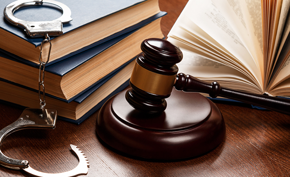

## 1-LOS DATOS

### 1.1 Datos originales

- Antes llamamos a los **paquetes** que nos haran falta :

```r
library(tidyverse)
library(eurostat)
library(rio)
library(gganimate)
library(viridis)
library(summarytools)
library(kableExtra)
library(gridExtra)
```

- Los datos originales recogen 6 tipos de delitos:
  - Homicidios
  - Actos que causan daño o pretenden causar daño a la persona, actos lesciosos de naturaleza sexual y actos contra la propiedad que impliquen violencia o amenaza contra una persona
  - Robos
  - Robos en residencias privadas
  - Robo de vehículo terrestre motorizado
  - Actos ilícitos que implican drogras o precursores controlados

para **39 paises Europeos**, desde **1993** hasta **2007**.

### 1.2 Descargar los datos

- Vamos a descargar los datos con el paquete de Eurostat directamente y empezar a limpiarlos con algunas funcciones del Tidyverse :

```r
df <- get_eurostat("crim_gen",time_format = 'raw')
df <- label_eurostat(df, code = c("geo","iccs"))

df <- df %>% select(geo_code,geo,iccs_code,iccs,time,values) %>%
             mutate(time = as.numeric(time)) %>%
             rename(infraccion = iccs, code_pais = geo_code, pais = geo, anyo = time, numinf = values)
```

Los datos tienen **6** variables y recogen en total **3532** valores.

### 1.3 Limpiar los datos

```r
df <- df %>% filter(code_pais !="FX" & iccs_code != "TOTAL") %>% filter(code_pais !="TR") #Quito Turquia tambien ^^

df <-df %>% mutate(infraccion = case_when(
            infraccion == "Intentional homicide" ~ "Homicidios",
            infraccion == "Acts causing harm or intending to cause harm to the person, injurious acts of a sexual nature and acts against property involving violence or threat against a person"  ~ "Actos violentos",
            infraccion == "Robbery"  ~ "Robos",
            infraccion == "Burglary of private residential premises"  ~ "Robo en residencias privadas",
            infraccion == "Theft of a motorized land vehicle"  ~ "Robo de vehiculos",
            infraccion == "Unlawful acts involving controlled drugs or precursors"  ~ "Actos ilicitos con drogas", TRUE ~ as.character(infraccion)))

df <-df %>% mutate(pais = case_when(
  pais == "Germany (until 1990 former territory of the FRG)" ~ "Germany",
  pais == "England and Wales"  ~ "RU",
  TRUE ~ as.character(pais)))
```

Ahora nos quedan **6** variables y recogen **2830** valores.

Para no volver a empenzar desde 0 hemos exportado nuestro **df** limpio en nuestra carpeta de datos del proyecto.

```r
rio::export(df, "./datos/df_crim_gen.rds")
```

### 1.4 ¿Cómo son los datos?

- Con la funccion *str()* podemos el tipo de datos de os que disponemos:

```
## Classes 'tbl_df', 'tbl' and 'data.frame':    2830 obs. of  6 variables:
##  $ code_pais : Factor w/ 39 levels "AT","BE","BG",..: 1 2 3 4 5 6 7 8 9 10 ...
##  $ pais      : chr  "Austria" "Belgium" "Bulgaria" "Switzerland" ...
##  $ iccs_code : Factor w/ 7 levels "ICCS0101","ICCS02-04",..: 1 1 1 1 1 1 1 1 1 1 ...
##  $ infraccion: chr  "Homicidios" "Homicidios" "Homicidios" "Homicidios" ...
##  $ anyo      : num  2007 2007 2007 2007 2007 ...
##  $ numinf    : num  45 211 169 51 11 126 757 76 93 128 ...
```

- Y con la funccion *dfSummary* tenemos un resumen de estos :

```
## Data Frame Summary
## df
## Dimensions: 2830 x 6
## Duplicates: 0
##
## ----------------------------------------------------------------------------------------------------------------------------------
## No   Variable      Stats / Values                   Freqs (% of Valid)     Graph                                Valid    Missing
## ---- ------------- -------------------------------- ---------------------- ------------------------------------ -------- ---------
## 1    code_pais     1. AT                              74 ( 2.6%)                                                2830     0
##      [factor]      2. BE                              48 ( 1.7%)                                                (100%)   (0%)
##                    3. BG                              70 ( 2.5%)
##                    4. CH                              74 ( 2.6%)
##                    5. CY                              90 ( 3.2%)
##                    6. CZ                              81 ( 2.9%)
##                    7. DE                              86 ( 3.0%)
##                    8. DK                              83 ( 2.9%)
##                    9. EE                              83 ( 2.9%)
##                    10. EL                             87 ( 3.1%)
##                    [ 29 others ]                    2054 (72.6%)           IIIIIIIIIIIIII
##
## 2    pais          1. Cyprus                          90 ( 3.2%)                                                2830     0
##      [character]   2. Hungary                         90 ( 3.2%)                                                (100%)   (0%)
##                    3. Italy                           90 ( 3.2%)
##                    4. Lithuania                       90 ( 3.2%)
##                    5. Norway                          90 ( 3.2%)
##                    6. Netherlands                     89 ( 3.1%)
##                    7. Poland                          89 ( 3.1%)
##                    8. Scotland                        89 ( 3.1%)
##                    9. Northern Ireland (UK)           88 ( 3.1%)
##                    10. Romania                        88 ( 3.1%)
##                    [ 27 others ]                    1937 (68.5%)           IIIIIIIIIIIII
##
## 3    iccs_code     1. ICCS0101                      499 (17.6%)            III                                  2830     0
##      [factor]      2. ICCS02-04                     460 (16.2%)            III                                  (100%)   (0%)
##                    3. ICCS0401                      469 (16.6%)            III
##                    4. ICCS05012                     478 (16.9%)            III
##                    5. ICCS050211                    467 (16.5%)            III
##                    6. ICCS0601                      457 (16.2%)            III
##                    7. TOTAL                           0 ( 0.0%)
##
## 4    infraccion    1. Actos ilicitos con drogas     457 (16.2%)            III                                  2830     0
##      [character]   2. Actos violentos               460 (16.2%)            III                                  (100%)   (0%)
##                    3. Homicidios                    499 (17.6%)            III
##                    4. Robo de vehiculos             467 (16.5%)            III
##                    5. Robo en residencias priva     478 (16.9%)            III
##                    6. Robos                         469 (16.6%)            III
##
## 5    anyo          Mean (sd) : 2000.7 (4.2)         15 distinct values             .     :   :                  2830     0
##      [numeric]     min < med < max:                                            :   :     :   :                  (100%)   (0%)
##                    1993 < 2001 < 2007                                      :   :   : . . : . :
##                    IQR (CV) : 7 (0)                                        : : : : : : : : : :
##                                                                            : : : : : : : : : :
##
## 6    numinf        Mean (sd) : 31370.1 (81961.6)    2387 distinct values   :                                    2830     0
##      [numeric]     min < med < max:                                        :                                    (100%)   (0%)
##                    0 < 4645.5 < 997607                                     :
##                    IQR (CV) : 21996 (2.6)                                  :
##                                                                            : .
## ----------------------------------------------------------------------------------------------------------------------------------
```

## 2-PREGUNTAS INTERESANTES

### 2.1 ¿Cuál es la evolución de los delitos en Europa?

- Dejamos el **código** para el primer mapa :

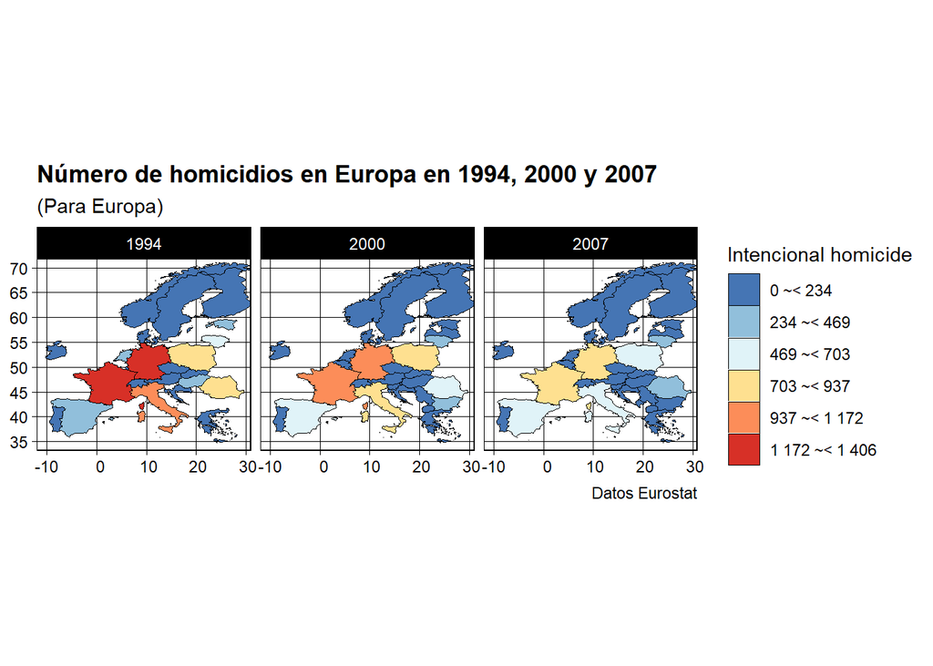

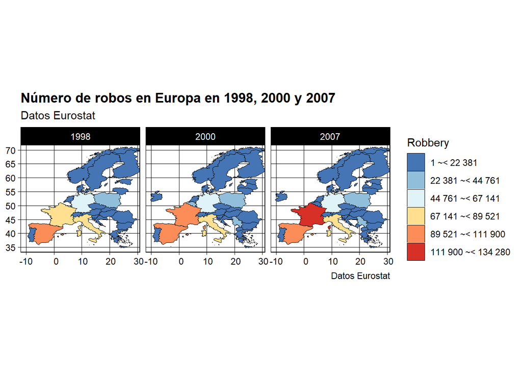

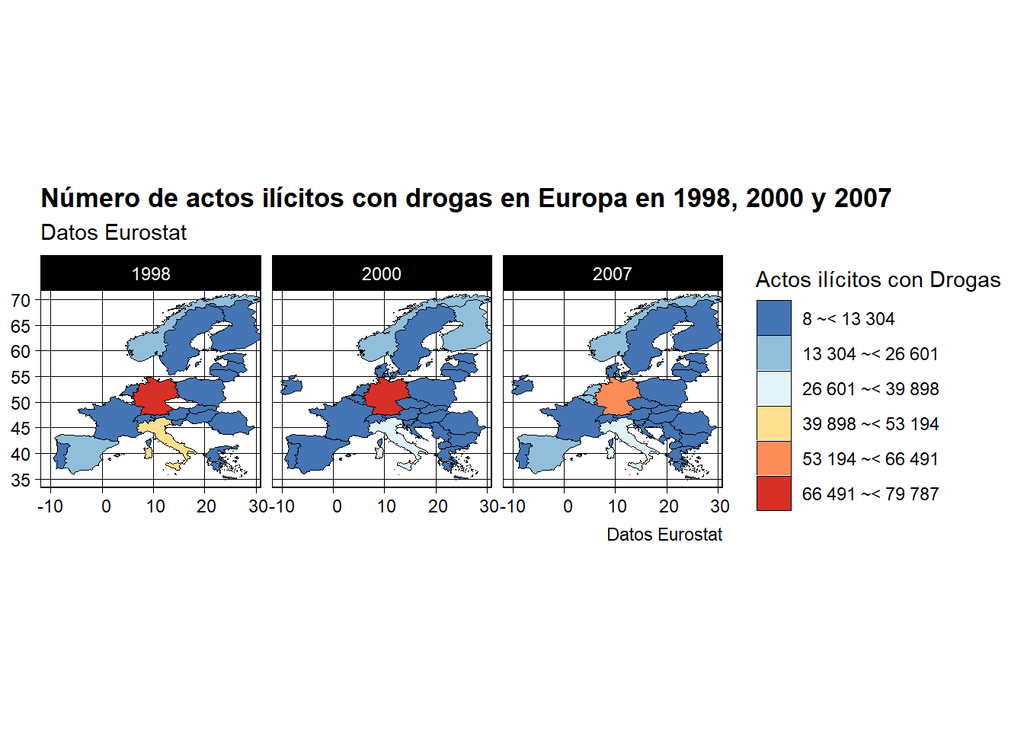

```r
df1a <- df %>% filter(iccs_code == "ICCS0101") %>%
  group_by(anyo, numinf) %>%
  arrange(numinf) %>%
  ungroup() %>%
  group_by(iccs_code) %>%
  mutate(cat_inf = cut_to_classes(numinf, n = 6)) %>%
  ungroup()


geometrias <- get_eurostat_geospatial(resolution = "20", nuts_level = "0")
mapdata <- full_join(df1a, geometrias, by = c("code_pais" = "id"))


mapdata_1a <- mapdata %>%  filter(iccs_code == "ICCS0101", anyo %in% c(1994,2000,2007))

p <- ggplot(mapdata_1a) +
     geom_sf(aes(fill = cat_inf, geometry = geometry), color = "black", size = .1) +
     facet_wrap( ~ anyo) +
     scale_fill_brewer(palette = "RdYlBu", direction = -1)  +
     labs(title = "Número de homicidios en Europa en 1994, 2000 y 2007",
     subtitle = "(Para Europa)",
     fill = "Intencional homicide",
     caption = "Datos Eurostat") +
     theme_linedraw() +
     coord_sf(xlim = c(-10,29), ylim = c(35,70))
p <- p + theme(plot.title = element_text(face = "bold"))+
         theme(axis.title.y = element_text(size=8))+
         theme(axis.title.x = element_text(size=8))
p
```

### 2.2 ¿Cuales son los 5 países europeos donde hay más infracciones en funccion de cada tipo de estas? *(homicidios, Robos, Actos violentos, etc)*

- Arreglamos un poco el **df** pasando a **df2**:

```r
df2 <- df %>% select(anyo, pais, infraccion, numinf) %>%
  group_by(anyo, pais, infraccion) %>%
  summarise(sum(NN = numinf)) %>%
  ungroup() %>%
  rename(numinf_total = 4)
```

- Como antes, para el Primer Grafico dejamos el **Código** asi podeis ver cómo lo hemos hecho :

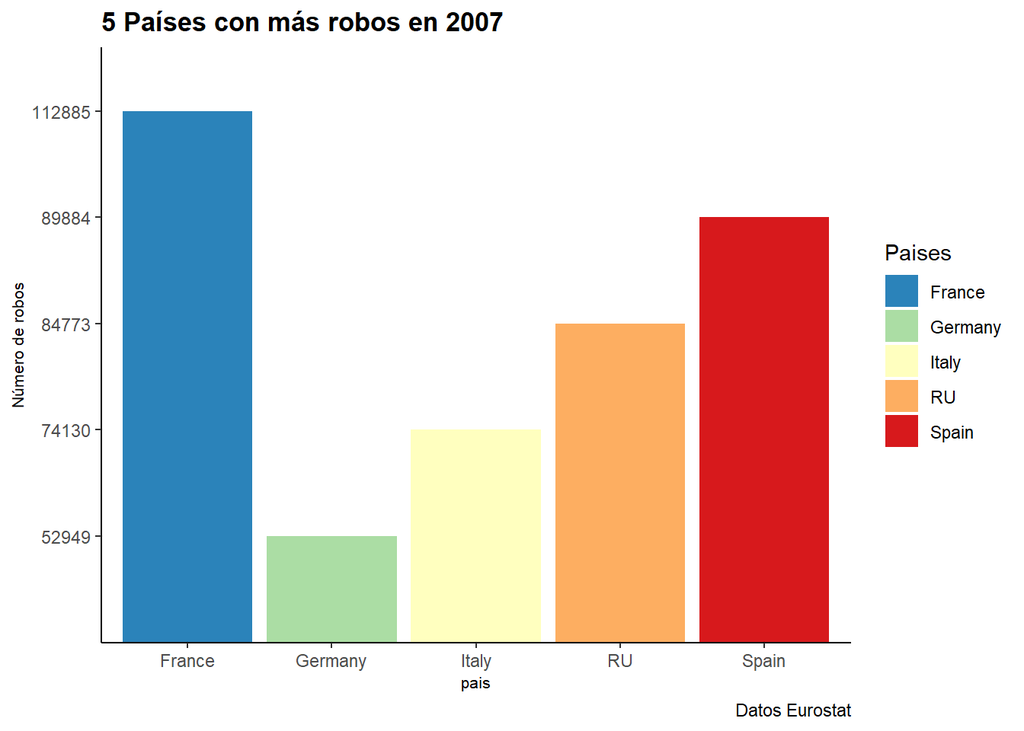

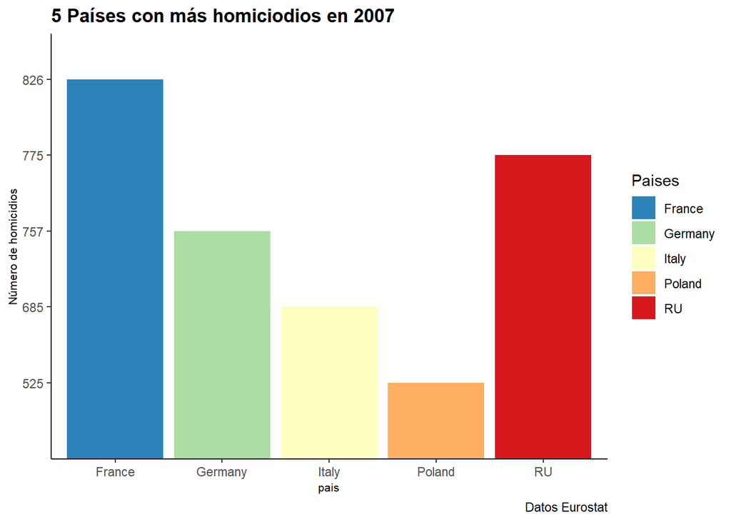

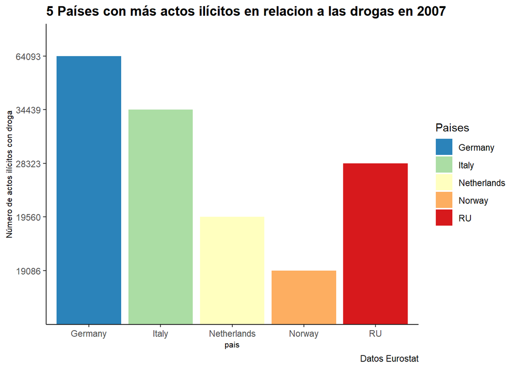

```r
df2a <- df2 %>% filter(infraccion == "Robos" & anyo == 2007) %>%
  group_by(pais) %>%
  summarise(sum(NN = numinf_total)) %>%
  ungroup() %>%
  rename(numinf_robos = 2) %>%
  arrange(desc(numinf_robos)) %>%
  slice(c(1:5))

df2a <- df2a %>%
  mutate(numinf_robos = forcats::as_factor(numinf_robos)) %>%
  mutate(numinf_robos = forcats::fct_infreq(numinf_robos))

p <- ggplot(df2a) +
     geom_col(mapping = aes(x = pais, y = fct_infreq(numinf_robos), fill = pais)) +
     scale_fill_brewer(palette = "Spectral", direction = -1)  +
     labs(title = "5 Países con más robos en 2007",
     fill = "Paises",
     caption = "Datos Eurostat") +
     ylab(label = "Número de robos") +
     theme_classic()
p <- p + theme(plot.title = element_text(face = "bold"))+
         theme(axis.title.y = element_text(size=8))+
         theme(axis.title.x = element_text(size=8))
p
```

#### a) Para Francia :

- Así hemos arreglado el **df** :

```r
df3a <- df %>% select(anyo, pais, infraccion, numinf) %>%
  filter(pais == "France" & anyo == 2007) %>%
  mutate(Prop_infraccion = (numinf/sum(numinf))*100) %>%
  arrange(Prop_infraccion) %>%
  ungroup()

df3b <- df3a %>% mutate(Prop_infraccion = forcats::as_factor(Prop_infraccion))
df3b <- df3b %>% mutate(Prop_infraccion = forcats::fct_infreq(Prop_infraccion))
```

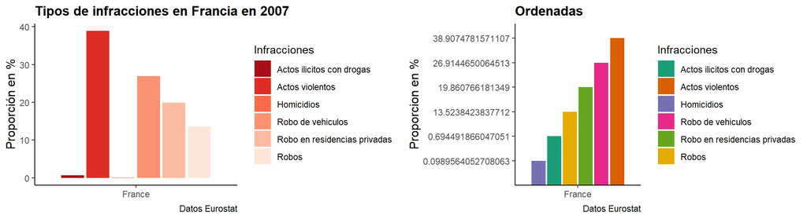

#### b) Para España :

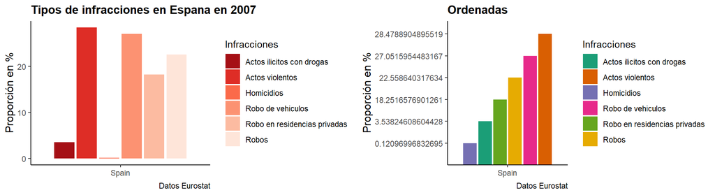

#### c) Para Francia, España, Alemania,RU al mismo tiempo:

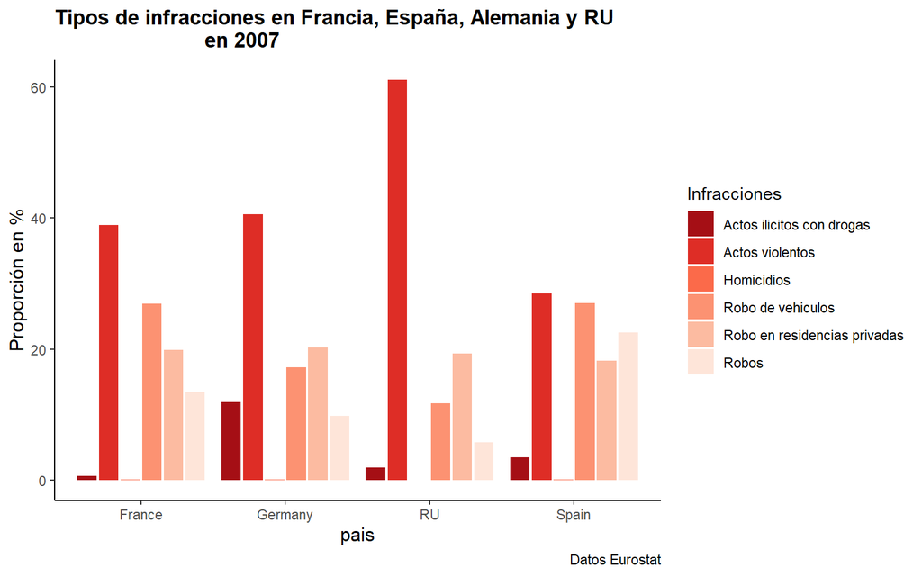

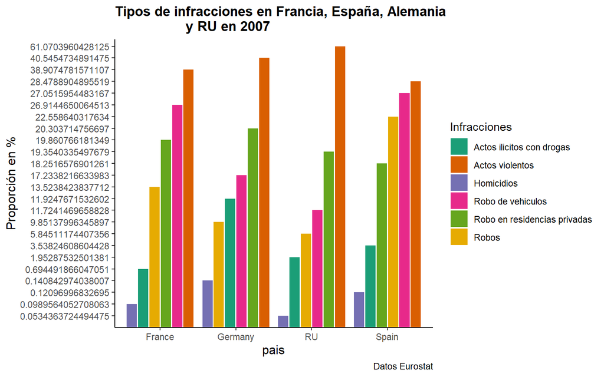

### 2.4 Mostrar la evolución del número de actos ílicitos en Europa y comparar

#### a) En toda Europa desde el año 1993 hasta el 2007 en un único gráfico:

Para ello hemos **reescalado** las infracciones para poder enseñarlas en el mismo gráfico y sobre todo poder comparar las evoluciones en terminos relativos.

```r
df4a <- df %>% select(anyo, pais, infraccion, numinf) %>%
               group_by(anyo, infraccion) %>%
               summarise(sum(NN = numinf)) %>%
               ungroup() %>%
               rename(numinf_total = 3)

#Reescalamos con la funccion rescaled_inf :
df4a <-df4a %>% group_by(infraccion) %>%
                mutate(rescaled_inf = 100*numinf_total/numinf_total[1])
```

- La gráfica :

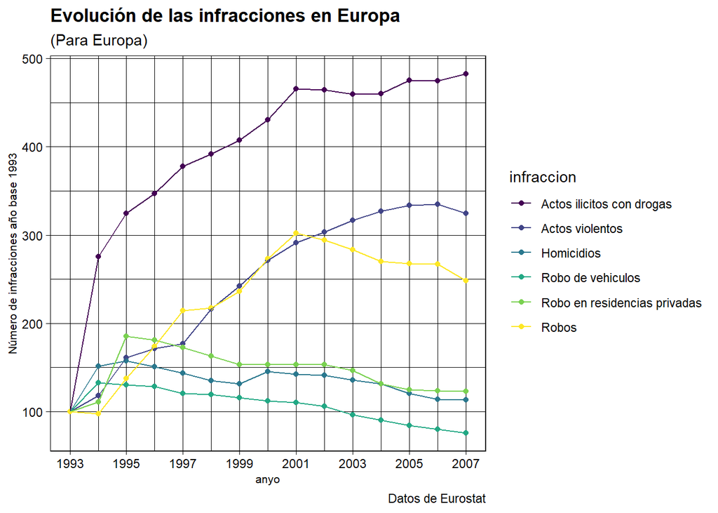

#### b) Vamos a comparar las evoluciones de cada tipo de delito entre Francia y España:

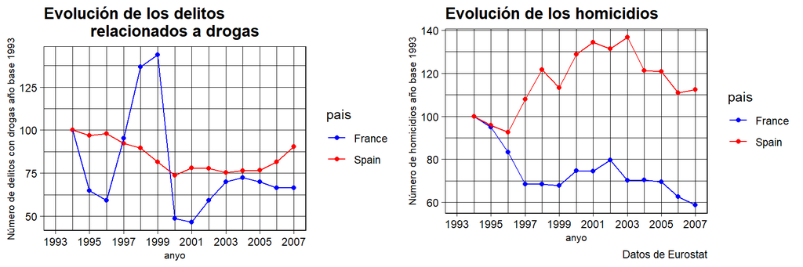

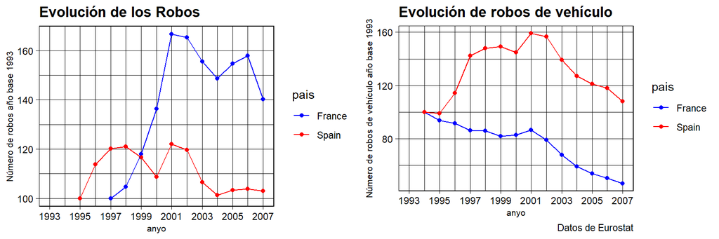

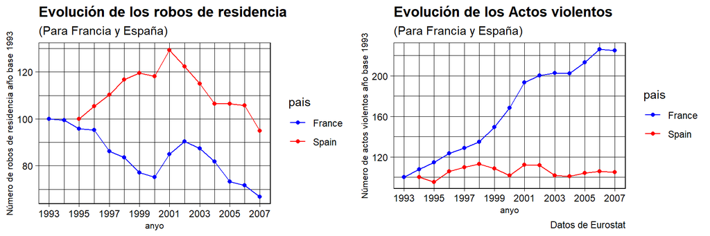

## 3-OTRAS PREGUNTAS INTERESANTES

### 3.1 ¿Están Francia y España por debajo o por encima de la media europea en números de infraccion?

Hemos conseguido contestar a esta pregunta con la funccion *case_when()*.  
* El **código** es :

```r
df_1 <-df %>%
  select(anyo,code_pais,pais,infraccion,numinf) %>%
  group_by(pais) %>%
  mutate(mean_pais = mean(numinf)) %>%
  ungroup()%>%
  mutate(mean_europ = mean(numinf)) %>%
  mutate(GOOD_or_BAD = case_when(
    mean_pais > mean_europ ~ "Bad",
    mean_pais < mean_europ ~ "Good"))
```

- Despues hemos descargado las **geometrias** del Eurostat :

```r
geometrias <- get_eurostat_geospatial(resolution = "20", nuts_level = "0")
mapdata <- full_join(df_1, geometrias, by = c("code_pais" = "id"))
```

- Y sale un gráfico así :

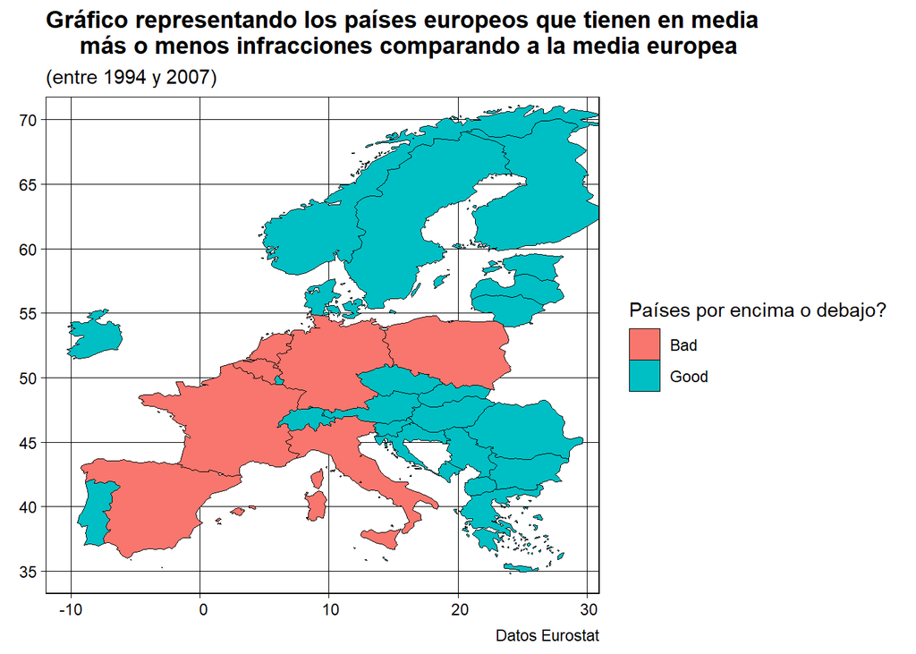

### 3.2 Muestra la evolución del número de infracciones por cada tipo para Francia y España

Como ya hemos contestado un poco a esta pregunta en los apartados anteriores ahora lo vamos a hacer pero de manera dinámica con el paquete *gganimate*.

#### a) Para los Homicidios :

- El **código** es :

[figure not shown]

```r
df_2a <- df %>% filter(pais %in% c("Spain","France") &  infraccion == "Homicidios")
p<-ggplot(df_2a, aes(anyo, numinf, group =pais, colour = pais)) +
   geom_line() +
   geom_point() +
   scale_colour_manual(values = c(France = "blue", Spain = "red")) +
   labs(title ="Evolución de los homicidios en Francia y España",
   subtitle = "(Desde 1993 hasta 2007)",
   caption = "Datos de Eurostat",
   y = "Número de homicidios") +
   scale_x_continuous(breaks = seq(1993, 2007, 2), limits = c(1993, 2007)) +
   transition_reveal(anyo)+
   theme_linedraw()
p <-p + theme(plot.title = element_text(face = "bold")) +
        theme(axis.title.y = element_text(size=12)) +
        theme(axis.title.x = element_text(size=12))
p
```

#### b) Para los delitos relacionados con drogas :

[figure not shown]

#### c) Para el resto de infracciones :

[figure not shown]

### 3.3 ¿Una Tabla?

Para la tabla hemos realizado una tabla que recoge para cada país el **porcentaje de cada tipo de infraccion** sobre las **infracciones totales** del país.

- Entonces el **código** es este :

```r
df_3 <- df %>% select(2,4,6) %>%
        group_by(pais) %>%
        mutate(numinf_total = sum(NN = numinf)) %>%
        group_by(pais,infraccion) %>%
        mutate(numinf_by_inf_and_country = sum(NN = numinf)) %>%
        mutate(percent = (numinf_by_inf_and_country/numinf_total)*100) %>%
        select(1,2,6) %>%
        slice(1:218) %>%
        mutate(row_num = 1:n()) %>%
        pivot_wider(names_from = infraccion, values_from = percent) %>%
        filter(row_num == "1") %>% select(-2) %>% mutate(Total = "100%")

#Para hacer la Tabla :
knitr::kable(df_3,format = "html") %>%
kableExtra::kable_styling(bootstrap_options = c("striped", "hover"),fixed_thead = list(enabled = T, background = "lightgrey"))
```

| pais | Actos ilicitos con drogas | Actos violentos | Homicidios | Robo de vehiculos | Robo en residencias privadas | Robos | Total |
| --- | --- | --- | --- | --- | --- | --- | --- |
| Austria | 4.1408903 | 49.084041 | 0.1298585 | 12.650911 | 28.525119 | 5.4691801 | 100% |
| Belgium | 4.8101086 | 43.273095 | 0.0975377 | 14.550799 | 26.991683 | 10.2767762 | 100% |
| Bulgaria | 2.3132794 | 13.362142 | 0.5215756 | 2.948007 | 73.032978 | 7.8220177 | 100% |
| Croatia | 29.5185755 | 42.131377 | 0.8129488 | 8.150941 | 13.008093 | 6.3780645 | 100% |
| Cyprus | 10.0023282 | 6.207353 | 0.2632663 | 34.822788 | 47.559862 | 1.1444025 | 100% |
| Czechia | 2.6535607 | 33.012907 | 0.2052390 | 38.850147 | 18.302592 | 6.9755544 | 100% |
| Denmark | 1.5520067 | 18.094992 | 0.0760375 | 40.509286 | 34.376261 | 5.3914171 | 100% |
| Estonia | 3.2033462 | 14.633031 | 1.1691045 | 16.086877 | 50.197709 | 14.7099322 | 100% |
| Finland | 10.4016105 | 45.379758 | 0.1840150 | 29.332181 | 12.631397 | 2.0710390 | 100% |
| France | 0.7229428 | 27.123103 | 0.1106335 | 38.896781 | 23.741546 | 9.4049941 | 100% |
| Germany | 10.3484691 | 30.865878 | 0.1696239 | 25.830197 | 25.023695 | 7.7621368 | 100% |
| Greece | 11.2088522 | 14.643157 | 0.2212833 | 12.095246 | 58.761444 | 3.0700174 | 100% |
| Hungary | 4.4185446 | 39.067228 | 0.3233566 | 20.581861 | 31.494514 | 4.1144956 | 100% |
| Iceland | 4.2412015 | NA | 0.1031159 | NA | 94.221027 | 1.4346559 | 100% |
| Ireland | 3.3131156 | 17.074680 | 0.1219067 | 32.507252 | 44.226405 | 2.7566397 | 100% |
| Italy | 5.3276338 | 16.806000 | 0.1219987 | 40.155057 | 27.276840 | 10.3124695 | 100% |
| Latvia | 6.8459986 | 20.174485 | 1.9050779 | 23.618307 | 31.679772 | 15.7763598 | 100% |
| Liechtenstein | 57.9767775 | 16.987434 | 0.0318117 | 1.670113 | 22.634007 | 0.6998568 | 100% |
| Lithuania | 1.3356886 | 22.480755 | 1.6854910 | 21.690364 | 34.842473 | 17.9652286 | 100% |
| Luxembourg | 18.5048875 | 21.483515 | 0.0769213 | 11.928712 | 42.493669 | 5.5122956 | 100% |
| Malta | 3.5130719 | 8.277165 | 0.2246732 | 41.753472 | 35.355392 | 10.8762255 | 100% |
| Montenegro | 7.7861587 | 45.987000 | 0.4101637 | 2.182905 | NA | 43.6337725 | 100% |
| Netherlands | 4.0475033 | 36.153266 | 0.0705004 | 15.151472 | 38.188296 | 6.3889621 | 100% |
| North Macedonia | 10.4062267 | 24.345168 | 1.4962505 | 16.167324 | 32.963713 | 14.6213171 | 100% |
| Northern Ireland (UK) | 0.6833994 | 55.941477 | 0.0990863 | 18.744435 | 20.352201 | 4.1794022 | 100% |
| Norway | 22.8944866 | 28.305697 | 0.0580880 | 28.114278 | 18.675133 | 1.9523177 | 100% |
| Poland | 0.9514115 | 31.033885 | 0.3565053 | 23.839150 | 28.886794 | 14.9322543 | 100% |
| Portugal | 4.1201614 | 21.968659 | 0.1414159 | 28.480730 | 25.663949 | 19.6250841 | 100% |
| Romania | 3.3437008 | 23.379852 | 1.7942400 | 5.546310 | 55.178737 | 10.7571596 | 100% |
| RU | 1.4355064 | 43.248512 | 0.0539820 | 24.388840 | 25.086532 | 5.7866271 | 100% |
| Scotland | 9.0836018 | 27.153522 | 0.1211306 | 27.348229 | 31.548662 | 4.7448542 | 100% |
| Serbia | 4.3418617 | 42.328235 | 0.2538511 | 5.882788 | 10.981496 | 36.2117689 | 100% |
| Slovakia | 2.3237595 | 51.151398 | 0.4827373 | 27.337276 | 13.990279 | 4.7145505 | 100% |
| Slovenia | 13.2688521 | 36.132420 | 0.3711793 | 17.387328 | 26.342970 | 6.4972511 | 100% |
| Spain | 3.1026066 | 26.658567 | 0.1168904 | 30.504520 | 18.592730 | 21.0246859 | 100% |
| Sweden | 2.7896268 | 44.434158 | 0.0530046 | 38.677594 | 9.695354 | 4.3502635 | 100% |
| Switzerland | 8.6229240 | 10.234387 | 0.0812109 | NA | 76.403247 | 4.6582311 | 100% |

- con el paquete *DT::datatable* saldría esto :

```r
DT::datatable(df_3)
```

|  | pais | Actos ilicitos con drogas | Actos violentos | Homicidios | Robo de vehiculos | Robo en residencias privadas | Robos | Total |
| --- | --- | --- | --- | --- | --- | --- | --- | --- |
| 1 | Austria | 4.14089028664243 | 49.0840414456938 | 0.129858450201396 | 12.6509110530934 | 28.5251186849004 | 5.46918007946847 | 100% |
| 2 | Belgium | 4.81010864875388 | 43.273095104936 | 0.0975376812979794 | 14.5507991006124 | 26.9916832903438 | 10.276776174056 | 100% |
| 3 | Bulgaria | 2.31327943359475 | 13.3621421239658 | 0.52157561095201 | 2.94800677832767 | 73.0329783422193 | 7.82201771094043 | 100% |
| 4 | Croatia | 29.5185754910329 | 42.1313772657352 | 0.812948753645945 | 8.15094098475892 | 13.0080929710287 | 6.37806453379831 | 100% |
| 5 | Cyprus | 10.0023282053119 | 6.20735354693125 | 0.263266292959865 | 34.8227877572219 | 47.559861740423 | 1.14440245715207 | 100% |
| 6 | Czechia | 2.65356065981283 | 33.0129071011322 | 0.205239038167138 | 38.8501468042976 | 18.30259200874 | 6.97555438785032 | 100% |
| 7 | Denmark | 1.55200667915558 | 18.0949916683054 | 0.0760374943506626 | 40.5092856132507 | 34.3762613978617 | 5.39141714707597 | 100% |
| 8 | Estonia | 3.20334623678262 | 14.6330310981788 | 1.16910446597906 | 16.0868774518719 | 50.1977085552467 | 14.709932191941 | 100% |
| 9 | Finland | 10.4016105436042 | 45.3797576128214 | 0.184015043458677 | 29.3321810268589 | 12.6313968115045 | 2.07103896175234 | 100% |
| 10 | France | 0.72294283294636 | 27.1231027777201 | 0.110633498244946 | 38.8967809228134 | 23.7415458436049 | 9.40499412467016 | 100% |

[output cut: 27 more lines]

### 4.1 Bibliografia

Para la realizacion del trabajo hemos utilizado todos los tutoriales de clase. Ademas hemos utilizado tutoriales de internet :

Para importar los datos : **IMPORT**

- [Tutorial for the eurostat R package](https://ropengov.github.io/eurostat/articles/eurostat_tutorial.html). Encontrado en internet et realizado por Leo Lahti, Janne Huovari, Markus Kainu, Przemyslaw Biecek.

Para limpiar los datos : **TIDY**

- [El Cheatsheet del Tidyr](https://tidyr.tidyverse.org/). Que esta en la plataforma *tidyverse.org*.

Para transformar los datos : **TRANSFORM**

- [R para Ciencia de Datos](https://es.r4ds.hadley.nz/). Un libro de *Garrett Grolemund* y *Hadley Wickham* que estaba en la guia docente.

Para hacer las graficas : **VISUALISE**

- [The R Graph Gallery](https://www.r-graph-gallery.com/). Visto en clase.
- [Otra Galeria](http://www.ggplot2-exts.org/gallery/). No visto en clase.

Para comunicar los resultados : **COMMUNICATE**

- [R Markdown: The Definitive Guide](https://bookdown.org/yihui/rmarkdown/). Un libro de *Yihui Xie*, *J. J. Allaire*, *Garrett Grolemund*.